# Brain regions involved in the recognition of happiness and s... : NeuroReport

### Journal Logo

[December 19, 2005 - Volume 16 - Issue 18](https://journals.lww.com/neuroreport/toc/2005/12190)

BRAIN IMAGING

# Brain regions involved in the recognition of happiness and sadness in music

Khalfa, Stéphanie; Schon, Daniele; Anton, Jean-Luc; Liégeois-Chauvel, Catherine

Author Information

NeuroReport [16(18):p 1981-1984, December 19, 2005.](https://journals.lww.com/neuroreport/toc/2005/12190)

## Abstract

Here, we used functional magnetic resonance imaging to test for the lateralization of the brain regions specifically involved in the recognition of negatively and positively valenced musical emotions. The manipulation of two major musical features (mode and tempo), resulting in the variation of emotional perception along the happiness–sadness axis, was shown to principally involve subcortical and neocortical brain structures, which are known to intervene in emotion processing in other modalities. In particular, the minor mode (sad excerpts) involved the left orbito and mid-dorsolateral frontal cortex, which does not confirm the valence lateralization model. We also show that the recognition of emotions elicited by variations of the two perceptual determinants rely on both common (BA 9) and distinct neural mechanisms.

## Introduction

In the musical domain, the perception of emotion is particularly important because music appears to be primarily dedicated to evoking emotions [<sup>1</sup>]. Neural networks underlying the emotional recognition in music have been studied only in a few experiments (such as [<sup>2,3</sup>]). According to the valence lateralization model [<sup>4,5</sup>], positive emotions such as happiness would rely on the greater left frontal area activity. In contrast, negative emotions such as sadness would depend upon the relatively greater right frontal involvement. Two electroencephalographic (EEG) studies have extended this model to the musical domain [<sup>6,7</sup>].

In order to verify this result and localize more precisely the brain regions involved, we used functional magnetic resonance imagery (fMRI), which has a better spatial resolution than EEG.

A positron emission tomography study [<sup>2</sup>] has already shown that recognition of pleasantness in music, explored by presenting volunteers with consonant and dissonant excerpts, appears to involve several distinct paralimbic (right para-hippocampic gyrus, subcallosum cingulate) and neocortical areas (orbitofrontal cortex, and frontal pole regions). The bilateral orbitofrontal cortex was thus involved in pleasantness judgement, but its involvement in positive and negative emotions processing was not explored. Happiness and sadness are the most reliable and distinguishable musically induced emotions [<sup>8</sup>]. They rely on two flexible musical features, the tempo (speed of the beat in music) and the mode (major or minor) [<sup>9</sup>]. Fast and major excerpts evoke a sense of happiness while slow and minor excerpts evoke a sense of sadness [<sup>10</sup>].

Our first aim was thus to test whether the recognition of happiness and sadness in music follows the valence lateralization model and whether it involves, as is the case for the recognition of pleasantness in consonant and dissonant excerpts, bilateral prefrontal structures.

Moreover, as mode and tempo processing seem to involve distinct neural mechanisms [<sup>11</sup>], the second aim of the study was to determine whether the recognition of emotions elicited by variations of these two perceptual determinants is processed by similar or distinct structures.

## Study participants and methods

### Volunteers

Thirteen healthy volunteers (eight men, five women) with a mean age of 28 years (range 22–39) were tested. All but one (a woman) were right-handed, following the Edinburgh Handedness Inventory scores [<sup>12</sup>]. Informed consent for participation in the study was obtained from volunteers after the nature of the experimental procedures had been explained. The ethical committee of Marseille 1 formally approved the present study.

### Stimuli

Three sorts of stimuli were used: fast excerpts (24), slow excerpts (24) and periods of silence (10-s duration). Two lists of stimuli were presented in a pseudo-randomized order. Each list included 12 silent periods, and 12 fast and 12 slow musical excerpts. Half of the musical stimuli in a list were in a major mode whereas the other half were in a minor mode.

### Procedure

Participants were asked to listen carefully to short musical excerpts presented through piezoelectric headphones. After each excerpt, their task was to judge the emotion represented in the music on a 5-point scale ranging from sad (1) to happy (5), by pushing one of the five buttons of a box placed under each finger of the right hand [from the thumb (score 1) to the little finger (score 5)]. Mean scores for each of the four types of excerpts in the 13 participants were calculated and compared using a one-way analysis of variance and pairwise multiple-comparisons tests (with Bonferroni correction).

### Image acquisition and analyses

fMRI was performed using a 3 T whole-body imager Medspec 30/80 AVANCE (Bruker, Ettlingen, Germany). High-resolution structural T1-weighted images were acquired from all the participants for anatomical localization (inversion-recovery 3D sequence, 1×0.75×1.22 mm) and covered the whole brain.

The functional images were acquired using a T2*-weighted echo-planar sequence using a sparse temporal sampling technique to circumvent the scanner noise interference. Participants were studied in two sessions of scans with a total duration of 40 min. In each session, volunteers were presented with one-half of the excerpts in a pseudo-randomized order. fMRI acquisition began directly following the end of each stimulus. After each 10 s excerpt, one set of 30 axial slices (4 mm) was acquired parallel to the anterior commissural–posterior commissural plane and covered frontal and temporal structures.

Statistical parametric mapping software (SPM99; Institute of Neurology, London, UK) was used for image processing and analysis. For each volunteer, the functional images were realigned to the first image session (co-registered with the corresponding T1-weighted data set), a slice timing was performed, and the images were then normalized to a standard space of template images based upon the Montreal Neurologic Institute system, and were finally spatially smoothed (3D Gaussian kernel: 6×6×6 mm). Second-order analyses (random effects) were carried out wherein results were expressed as statistical parametric maps (SPM{*t*}) calculated for each voxel. Contrasts were tested for tempo effect (fast versus slow), mode effect (major versus minor) as well as tempo–mode interaction effect. The threshold used was *P*<0.05, corrected for multiple comparisons (Family Wise Error). For each volunteer, subtractions were performed to identify regional changes according to mode, tempo and both mode and tempo. The coordinates of the cluster maxima were transformed (http://www.mrc-cbu.cam.ac.uk/Imaging/) to fit in the Talairach space [<sup>13</sup>].

## Results

### Behavioural results

One-way repeated measures analysis of variance performed on emotional judgements showed an effect of the excerpt type (F(3,36)=83.32, *P*<0.0001) with significant differences (*P*<0.0001) between all conditions. Fast major excerpts were rated as the happiest excerpts (mean=4.2±0.5) followed by fast minor (3.4±0.4), slow major (mean=2.7±0.3) and slow minor excerpts (mean=1.9±0.3).

### Funtional magnetic resonance imagery results

While no main tempo effect was evident when contrasting slow and fast excerpts (*P*>0.05), mode effect was significant. Indeed, contrasting minor with major excerpts revealed activations in the left medial (BA 10) and superior (BA 9) frontal gyri and in both the right and left posterior cingulum gyri (BA 31) (Fig. 1). Contrasting major with minor excerpts, however, did not show any voxel activation.

[figure not shown]

Fig. 1:

Statistical activation maps for the minor–major contrast, and their stereotaxic coordinates, *z*-score and *P* values. Images are sagittal (left corner), coronal (right) and axial (left) sections for the random effect across volunteers. The right hemisphere of the brain corresponds to the right side of the image.

The interaction contrast for mode and tempo conditions also showed general significant activations in the left medial frontal gyrus (BA 9), in the right middle frontal gyrus (BA 6) and in the right anterior cingulate gyrus (BA 24) (Fig. 2). Post-hoc tests of simple comparisons for the mode–tempo interaction did not evidence any significant result.

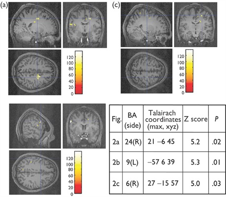

Fig. 2:

Statistical activation maps for the mode–tempo interaction, and their stereotaxic coordinates, *z*-score and *P* values. Images are sagittal (left corner), coronal (right) and axial (left) sections for the random effect across volunteers. The right hemisphere of the brain corresponds to the right side of the image.

## Discussion

### Behavioural results

In line with previous results [<sup>11,14</sup>], the mode and tempo manipulations of the musical excerpts evoked the predicted happiness sadness emotions variations. Contrary to a previous study [<sup>14</sup>], tempo manipulations have more influence on the emotional changes than mode manipulations because fast excerpts (minor and major) were judged as happy whereas slow excerpts (minor and major) were considered sad. This difference might be explained by the existence of larger tempo changes in the present study.

### fMRI

First, results of the minor versus major mode contrast showed a larger activity in the posterior cingulate cortex, and in the left orbito and mid-dorsolateral frontal cortex. Given that the minor mode rather conveys sadness and the major mode conveys happiness, the greater left prefrontal activity in response to sadness relative to happiness does not fit well with the valence lateralization model nor with previous results obtained with EEG recordings in the musical domain [<sup>6,7</sup>]. This discrepancy may be due to differences between experimental designs, and methodologies, especially concerning the emotional load of the musical excerpts (and their duration), and the reference condition [<sup>7,15</sup>]. As minor and major excerpts contain the same number of fast and slow excerpts, the arousal levels are the same in both mode conditions, and the attention required for the recognition task should not vary. Consequently, differences in arousal or in attention levels may not explain our results. In contrast, our results are in accordance with other neuroimaging studies that do not support the prefrontal valence lateralization hypothesis but suggest that this lateralization depends upon a more complex regional specificity [<sup>16</sup>]. This may explain the differences in the results from the EEG and fMRI studies as the two methods did not detect the same brain activations. fMRI has a better spatial resolution and allows the detection of subcortical limbic activations. On the contrary, EEG recordings are not sensitive to deeper brain structures but have a more coarse localization of the valence.

Whatever the orbitofrontal cortex functional asymmetry in musical emotions recognition, our results fit well with a previous meta-analysis [<sup>17</sup>] showing the orbitofrontal implication in emotion processing. Its role does not seem to be limited to the valence differentiation. For example, the BA 10 might be specialized for introspective evaluation of one's own thoughts and feelings [<sup>18</sup>]. Such an introspective assessment is probably required when judging the happiness–sadness variations in music.

Second, our results do not replicate a previous study exploring the emotional responses to pleasantness in music [<sup>2</sup>]. In this experiment, manipulation of the consonance/dissonance dimension involved the bilateral ventromedial part of the orbitofrontal cortex (BA 14). This discrepancy can be explained by the differences between stimuli used because dissonant music represents an aversive stimulus whereas sad excerpts are rather pleasant even if they represent a negative emotion [<sup>19</sup>].

Third, according to the partial overlap observed in the brain areas sensitive to the mode dimension (BA 9, BA 10, BA 31) and to the mode–tempo interaction (BA 6, BA 9, BA 24), one may argue that the recognition of emotions elicited by variations of these two perceptual determinants relies on both common and distinct neural mechanisms. The common BA 9 involvement in ratings of happiness–sadness in music supports the hypothesis of a role of BA 9 in the general processing of affect-related meanings [<sup>20</sup>].

## Conclusion

The present experiment mainly supports previous studies that did not confirm the valence lateralization model. It also demonstrates that the role of mode and tempo in music emotional discrimination relies at least on the orbitofrontal and cingulate cortices that are also involved in emotional processing in other domains.

## References

1. Sloboda JA. Musical structure and emotional response: some empirical findings. Psychol Music 1991; 19:110–120.

- Cited Here |
- [PubMed](http://www.ncbi.nlm.nih.gov/pubmed/) | [CrossRef](https://doi.org/10.1177%2F0305735691192002)

2. Blood A, Zatorre R, Bermudez P, Evans A. Emotional responses to pleasant and unpleasant music correlate with activity in paralimbic brain regions. Nat Neurosci 1999; 2:382–387.

- Cited Here |
- [PubMed](http://www.ncbi.nlm.nih.gov/pubmed/10204547) | [CrossRef](https://doi.org/10.1038%2F7299)

3. Alfredson B, Risberg J, Hagberg B, Gustafson L. Right temporal lobe activation when listening to emotionally significant music. Appl Neuropsychol 2004; 11:161–166.

4. Davidson RJ. The neuropsychology of emotion and affective style. In: Lewis M, Haviland JM, editors. Handbook of emotion. New York: Guilford Press; 1993. pp. 143–154.

5. Fox NA. If it's not left, it's right: electroencephalograph asymmetry and the development of emotion. Am Psychol 1991; 46:863–872.

6. Schmidt LA, Trainor LJ. Frontal brain electrical activity (EEG) distinguishes valence and intensity of musical emotions. Cognition Emotion 2001; 15:487–500.

7. Altenmueller E, Schurmann K, Lim VK, Parlitz D. Neuropsychologia 2002; 40:2242–2256.

8. Balkwil L, Thompson W. A cross-cultural investigation of the perception of emotion in music: psychophysical and cultural cues. Music Perception 1999; 17:43–64.

9. Krumhansl C. An exploratory study of musical emotions and psychophysiology. Can J Psychol 1997; 51:336–352.

10. Peretz I, Gagnon L, Bouchard B. Music and emotion: perceptual determinants, immediacy, and isolation after brain damage. Cognition 1998; 68:111–141.

11. Peretz I, Zatorre R. Brain organization for music processing. Annu Rev Psychol 2005; 56:89–114.

12. Oldfield R. The assessment and analysis of handedness: the Edinburgh inventory. Neuropsychologia 1971; 9:97–113.

13. Talairach J, Tournoux P. Coplanar stereotaxic atlas of the human brain. New York: Thieme; 1988. 122pp.

14. Dalla Bella S, Peretz I, Rousseau L, Gosselin N. A developmental study of the affective value of and mode in music. Cognition 2001; 80:1–9.

15. Baumgartner T, Esslen M, Jancke L. From emotion perception to emotion experience: emotions evoked by pictures and classical music. Int J Psychophysiol 2005 (in press).

16. Wager TD, Luan Phan K, Liberzon I, Taylor SF. Valence, gender, and lateralization of functional brain anatomy in emotion: a meta-analysis of findings from neuroimaging. Neuroimage 2003; 19:513–531.

17. Kringelbach M, Rolls E. The functional neuroanatomy of the human orbitofrontal cortex: evidence from neuroimaging and neuropsychology. Progrs Neurobiol 2004; 72:341–372.

18. Christoff K, Gabrieli J. The frontopolar cortex and human cognition: evidence for a rostrocaudal hierarchical organization within the human prefrontal cortex. Psychobiology 2000; 28:168–186.

19. Khalfa S, Peretz I, Blondin JP, Manon R. Event-related skin conductance responses to musical emotions in humans. Neurosci Lett 2002; 328:145–149.

20. Teasdale J, Howard R, Cox S, Ha Y, Brammer M, Williams S. Functional MRI study of the cognitive generation of affect. Am J Psychiatry 1999; 156:209–215.

**Keywords:**

emotion; functional magnetic resonance imagery; mode; music; tempo

© 2005 Lippincott Williams & Wilkins, Inc.

[figure not shown]

- June 2003

[figure not shown]

- November 2013

[figure not shown]

- March 2019

[figure not shown]

- January 2008

[figure not shown]

- August 2000

[figure not shown]

- November 2022

## Article Keywords

[output not shown]